# Preliminary analysis from the output from the *retentionmort* or *retentionmort_generation* functions

Brendan Campbell* (bpc@udel.edu), Jasper McCutcheon, Rileigh E. Hudock, Noah Motz, Madison Windsor, Aaron Carlisle, Edward Hale

V1: 2024-10-07

## This markdown will generate a series of preliminary figures using the *datacomp* dataframe that was created from either retentionmort function.

Install packages and load the dataset named *datacomp* from either the *retentionmort_generation* or the *retentionmort* function

- dplyr
- ggplot2
- gridExtra
- patchwork
- readr

## Preliminary data exploration

Table of relevant data outputs

```
##                        Minimum  Maximum  Average       SD
## Obs. Tags at Large      494.00 11458.00  6095.18  3351.00
## Exp. Tags at Large      494.00  6509.40  3668.98  1753.36
## Obs. Recaptures           0.00  2006.00   576.64   550.00
## Exp. Recaptures           0.00  2881.75   807.21   794.34
## PSE of Recaptures (%)     0.11    31.04    25.06     7.56
```

Paired T-Test of expected vs. observed tags at large

```r
print(ttest_tagsatlarge)
```

```
##
##  Paired t-test
##
## data:  TAsum and TaL
## t = -10.131, df = 44, p-value = 4.459e-13
## alternative hypothesis: true mean difference is not equal to 0
## 95 percent confidence interval:
##  -2908.824 -1943.575
## sample estimates:
## mean difference
##         -2426.2
```

Paired T-Test of expected vs. observed recaptures

```r
print(ttest_recapture)
```

```
##
##  Paired t-test
##
## data:  RA and R
## t = 6.305, df = 44, p-value = 1.201e-07
## alternative hypothesis: true mean difference is not equal to 0
## 95 percent confidence interval:
##  156.8666 304.2644
## sample estimates:
## mean difference
##        230.5655
```

## Exploratory Figures

1. Histogram of percent standard error (PSE) between estimated and observed number of tags at large

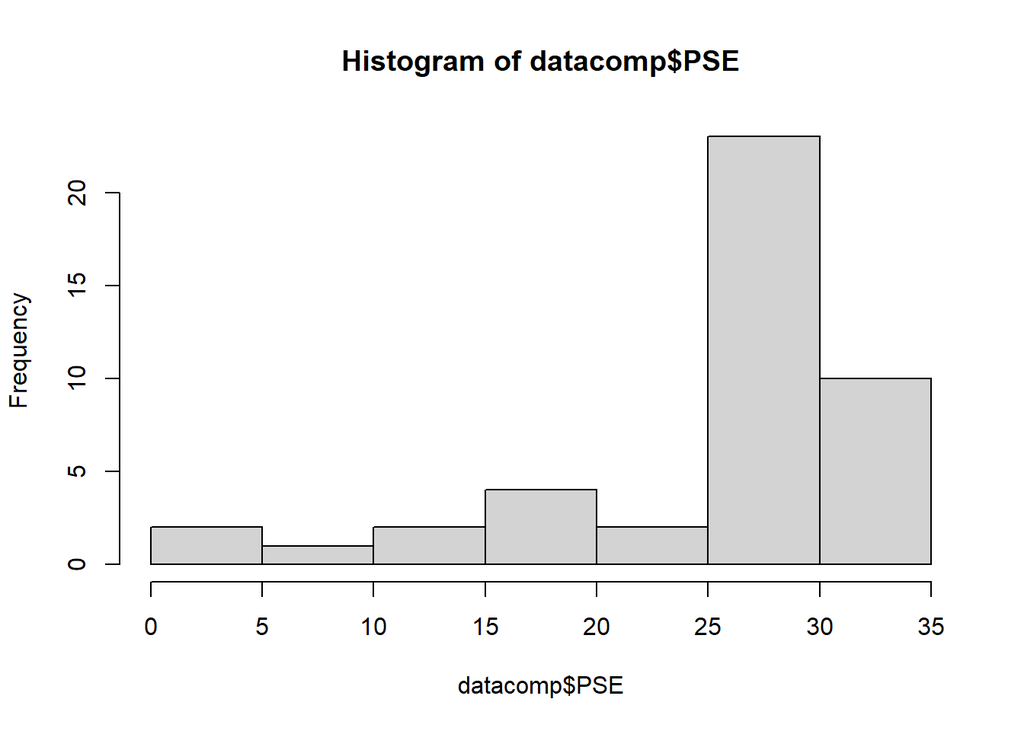

2. Percent standard error as a function of the number of observed tags at large. A red line is drawn at the 20% standard error, orange at 15%, yellow at 10%, and green at 5% to denote potential error thresholds for data.

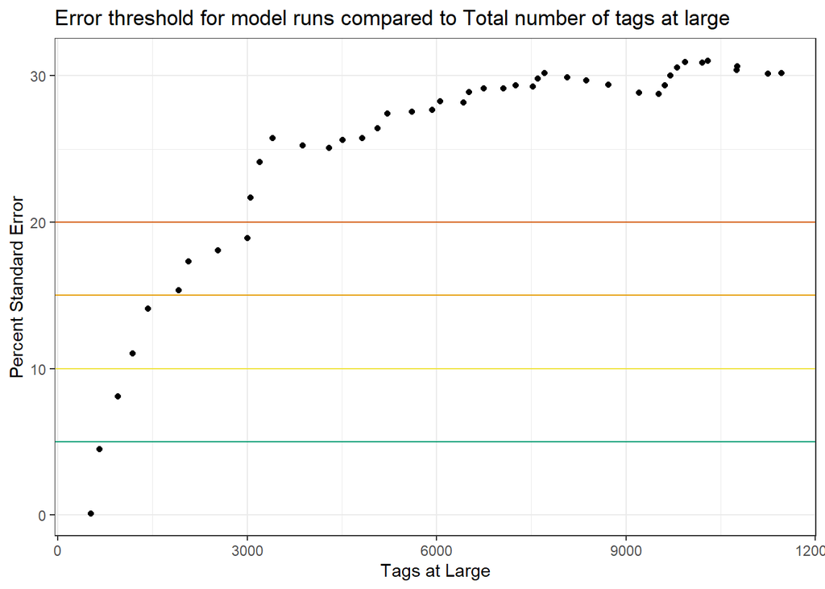

3. Deviation between predicted and observed number of recaptures. Blue line indicates a perfect 1:1 match while green indicates 5% deviation, yellow 10%, orange 15%, red 20%.

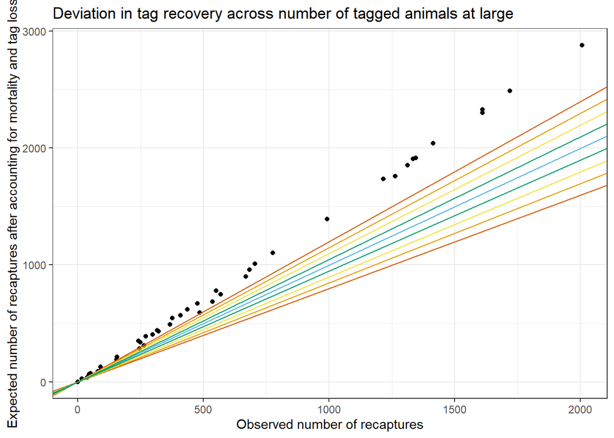

4. Percent standard error between expected and observed tags at large compared to the number of tagging efforts conducted. Red line indicates 20% PSE, orange 15%, yellow 10%, and green 5% PSE.

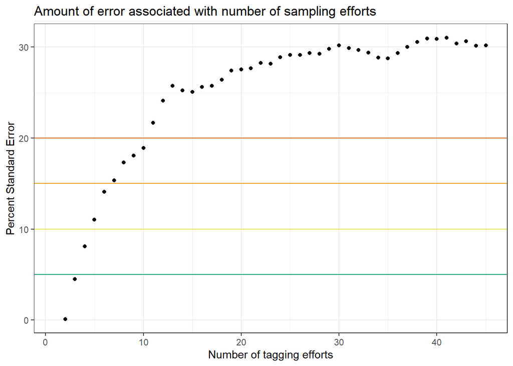

5. Determine the critical points in the number of tags at large from each model run that results in percent standard errors exceeding 5%, 10%, 15%, and 20% thresholds. A blank figure denotes no critical points that exceed the PSE threshold. This plot will likely only work for generated data using the *retentionmort_generation* function. The table below summarizes the data represented for each error threshold.

[figure not shown]

```
##                  Minimum Maximum Median Average SD    n
## 4.5 - 5.5% PSE       Inf    -Inf                      0
## 9.5 - 10.5% PSE      Inf    -Inf                      0
## 14.5 - 15.5% PSE    1916    1916   1916    1916       1
## 19.5 - 20.5% PSE     Inf    -Inf                      0
```

6. Determine the critical points in recapture efforts from each model run that results in percent standard errors exceeding 5%, 10%, 15%, and 20% thresholds. A blank figure denotes no critical points that exceed the PSE threshold. This plot will likely only work for generated data using the *retentionmort_generation* function. The table below summarizes the data represented for each error threshold.

[figure not shown]

```
##                  Minimum Maximum Median Average SD    n
## 4.5 - 5.5% PSE       Inf    -Inf                      0
## 9.5 - 10.5% PSE      Inf    -Inf                      0
## 14.5 - 15.5% PSE     264     264    264     264       1
## 19.5 - 20.5% PSE     Inf    -Inf                      0
```